# Untitled

Arina

2024-11-04

```r
trauma <- read.csv("C:/Users/Huawei/Desktop/biostat_2024-2025/Специфика мед данных/trauma - Sheet1.csv")
```

#Задание 1 ##Описательная статистика для переменных

```r
sum(is.na(trauma)) #поиск NA
```

```
## [1] 0
```

```r
#Меняем знаки
trauma$Height = gsub('"', '', trauma$Height)
trauma$Weight = gsub(',', '.', trauma$Weight)
trauma$Hb = gsub(',', '.', trauma$Hb)

trauma
```

| id | Name | Sex | Age | Height | Weight | SBP | DBP | FOUR | GSC | Hb | Death |
| --- | --- | --- | --- | --- | --- | --- | --- | --- | --- | --- | --- |
| 1 | Jecelle Oberly | Female | 24 | 68 | 176 | 102 | 78 | 10 | 8 | 11.4 | 1 |
| 2 | Halie Mccone | Female | 35 | 69.8 | 183.9 | 116 | 86 | 9 | 7 | 12.2 | 0 |
| 3 | Kole Cook | Male | 39 | 72.8 | 210.1 | 122 | 102 | 12 | 12 | 15 | 0 |
| 4 | Patricia Davis | Female | 20 | 70.5 | 195.4 | 120 | 100 | 11 | 9 | 12.2 | 0 |
| 5 | Grace Cress | Female | 63 | 66.8 | 169 | 112 | 84 | 9 | 7 | 12.4 | 1 |
| 6 | Joseph Benbrook | Male | 60 | 72.4 | 201.6 | 118 | 88 | 13 | 11 | 15 | 0 |
| 7 | Kelsie Coombs | Female | 63 | 69.6 | 216 | 122 | 100 | 10 | 9 | 11.8 | 0 |
| 8 | Aaron Eddy | Male | 26 | 74.7 | 194.1 | 114 | 94 | 11 | 10 | 14.4 | 0 |
| 9 | Victoria Hartman-Crowe | Female | 20 | 69.5 | 192.1 | 104 | 84 | 10 | 9 | 11.4 | 0 |
| 10 | Lindsay Locher | Female | 25 | 69.1 | 170.5 | 106 | 78 | 7 | 5 | 12.2 | 1 |

[output cut: 1014 more lines]

##Изменение типа данных

```r
trauma_1 <- trauma %>%
 mutate(id = as.factor(id),
        FOUR = as.factor(FOUR),
        GSC = as.factor(GSC),
        Death = as.factor(Death),
        Age = as.numeric(Age),
        SBP = as.numeric(SBP),
        DBP = as.numeric(DBP),
        Height = as.numeric(Height),
        Hb = as.numeric(Hb),
        Weight = as.numeric(Weight))
```

```r
trauma_1 %>%
  summary()
```

```
##        id           Name               Sex                 Age
##  1      :   1   Length:1024        Length:1024        Min.   :18.00
##  2      :   1   Class :character   Class :character   1st Qu.:29.00
##  3      :   1   Mode  :character   Mode  :character   Median :41.00
##  4      :   1                                         Mean   :40.94
##  5      :   1                                         3rd Qu.:53.00
##  6      :   1                                         Max.   :64.00
##  (Other):1018
##      Height          Weight           SBP             DBP              FOUR
##  Min.   :63.80   Min.   :133.3   Min.   : 90.0   Min.   : 58.00   8      :131
##  1st Qu.:69.70   1st Qu.:181.7   1st Qu.:106.0   1st Qu.: 78.00   10     :129
##  Median :72.80   Median :193.9   Median :110.0   Median : 84.00   9      :122
##  Mean   :72.42   Mean   :193.5   Mean   :110.8   Mean   : 84.78   7      :114
##  3rd Qu.:75.10   3rd Qu.:205.4   3rd Qu.:116.0   3rd Qu.: 90.00   11     :105
##  Max.   :79.90   Max.   :253.1   Max.   :134.0   Max.   :110.00   6      : 91
##                                                                   (Other):332
##       GSC            Hb       Death
##  8      :150   Min.   : 0.0   0:615
##  7      :135   1st Qu.:12.0   1:409
##  9      :128   Median :13.1
##  6      :107   Mean   :12.8
##  10     :105   3rd Qu.:14.0
##  5      : 93   Max.   :16.2
##  (Other):306
```

##Все нули в Hb заменяем на NA (пропущенные значения)

```r
trauma_2 <- trauma_1 %>%
  mutate(Hb = na_if(Hb, 0))
```

##Пациенты с низким гемоглобином

```r
low_Hb_Male <- trauma_2 %>%
  filter(Hb < 13.5 & Sex == "Male", na.rm = TRUE) %>%
     nrow()

low_Hb_Female <- trauma_2 %>%
  filter(Hb < 12 & Sex == "Female", na.rm = TRUE) %>%
     nrow()


low_Hb_Female + low_Hb_Male  #количество пациентов с низким гемоглобином
```

```
## [1] 458
```

```r
(low_Hb_Female + low_Hb_Male) / (nrow(trauma_2) - sum(is.na(trauma_2$Hb))) * 100 #процент пациентов с низким гемоглобином без пропущенных значений гемоглобина
```

```
## [1] 45.43651
```

```r
(low_Hb_Female + low_Hb_Male) / nrow(trauma_2) * 100 #процент пациентов с низким гемоглобином
```

```
## [1] 44.72656
```

##Меняем размерность переменных (для роста и веса)

```r
trauma_3 <- trauma_2 %>%
  mutate(across(Height, function(x) x*2.54) %>% round(1),
         across(Weight, function(x) x/2.2) %>% round(1))

trauma_3
```

| id | Name | Sex | Age | Height | Weight | SBP | DBP | FOUR | GSC | Hb | Death |
| --- | --- | --- | --- | --- | --- | --- | --- | --- | --- | --- | --- |
| 1 | Jecelle Oberly | Female | 24 | 172.7 | 80.0 | 102 | 78 | 10 | 8 | 11.4 | 1 |
| 2 | Halie Mccone | Female | 35 | 177.3 | 83.6 | 116 | 86 | 9 | 7 | 12.2 | 0 |
| 3 | Kole Cook | Male | 39 | 184.9 | 95.5 | 122 | 102 | 12 | 12 | 15.0 | 0 |
| 4 | Patricia Davis | Female | 20 | 179.1 | 88.8 | 120 | 100 | 11 | 9 | 12.2 | 0 |
| 5 | Grace Cress | Female | 63 | 169.7 | 76.8 | 112 | 84 | 9 | 7 | 12.4 | 1 |
| 6 | Joseph Benbrook | Male | 60 | 183.9 | 91.6 | 118 | 88 | 13 | 11 | 15.0 | 0 |
| 7 | Kelsie Coombs | Female | 63 | 176.8 | 98.2 | 122 | 100 | 10 | 9 | 11.8 | 0 |
| 8 | Aaron Eddy | Male | 26 | 189.7 | 88.2 | 114 | 94 | 11 | 10 | 14.4 | 0 |
| 9 | Victoria Hartman-Crowe | Female | 20 | 176.5 | 87.3 | 104 | 84 | 10 | 9 | 11.4 | 0 |
| 10 | Lindsay Locher | Female | 25 | 175.5 | 77.5 | 106 | 78 | 7 | 5 | 12.2 | 1 |

[output cut: 1014 more lines]

##Описательная статистика

```r
trauma_3 %>%
    select(Age,
           Death,
           Height,
           Weight,
           SBP,
           DBP,
           Hb) %>%
    tbl_summary(by = Death) %>%
    add_p()
```

| **Characteristic** | **0** N = 615<sup>1</sup> | **1** N = 409<sup>1</sup> | **p-value**<sup>2</sup> |
| --- | --- | --- | --- |
| Age | 40 (29, 52) | 43 (30, 53) | 0.14 |
| Height | 185 (178, 191) | 185 (176, 190) | 0.3 |
| Weight | 88 (83, 94) | 88 (82, 93) | 0.3 |
| SBP | 114 (108, 118) | 106 (102, 110) | <0.001 |
| DBP | 88 (82, 94) | 80 (76, 86) | <0.001 |
| Hb | 13.50 (12.50, 14.30) | 12.70 (11.40, 13.30) | <0.001 |
| Unknown | 10 | 6 |  |

<sup>1</sup> Median (Q1, Q3)  
<sup>2</sup> Wilcoxon rank sum test

Так как p-value меньше 0,05 для SBP, DBP, Hb, то эти параметры влияют на смерность при черепно-мозговой травме.

#Задание 2

```r
trauma_IMT <- trauma_3 %>%
  mutate('ИМТ' = Weight/Height*100 %>% round(1))

mean(trauma_IMT$ИМТ) #средний уровень ИМТ
```

```
## [1] 47.82703
```

```r
trauma_high_IMT <- trauma_IMT %>%
  filter(ИМТ > 30) %>%
  nrow()

trauma_high_IMT / nrow(trauma_IMT) *100 #доля пациентов с ожирением
```

```
## [1] 100
```

#Задание 3 ##ROC-кривая

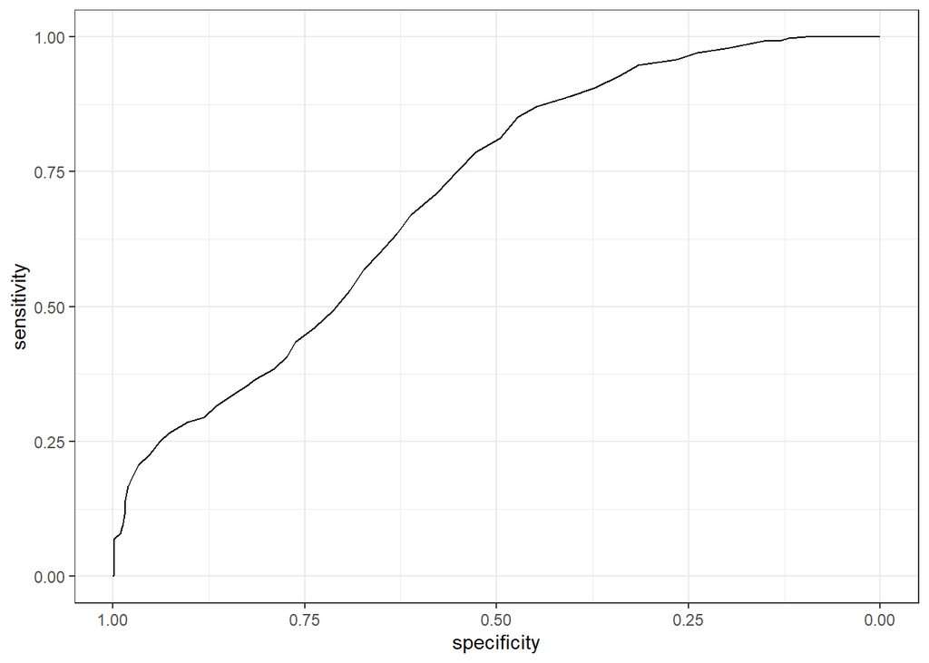

```r
roc_curve_1 <- roc(Death ~ Hb,
                   data = trauma_3,
                   ci = T)
roc_curve_1 %>%
    ggroc() +
    theme_bw()
```

Кривая выше, чем диагональ, то есть плошадь под кривой больше 0.5. Это может говорить о том, что признак подходит для прогностической диангостики, то есть это не случайная диагностика (количественный признак не рандомно проводит классификацию по двум группам, а отклоняется от диагонали)

#Задание 4 ##Площадь под ROC-кривой и доверительный интервал

```r
roc_curve_1 <- roc(Death ~ Hb,
                   data = trauma_3,
                   ci = T)
roc_curve_1
```

```
##
## Call:
## roc.formula(formula = Death ~ Hb, data = trauma_3, ci = T)
##
## Data: Hb in 605 controls (Death 0) > 403 cases (Death 1).
## Area under the curve: 0.7078
## 95% CI: 0.6763-0.7392 (DeLong)
```

Площадь под кривой - 0.7078 В доверительный интервал не входит 0,5, значит площадь под кривой значимо отличается от 0,5 => можем отвергнуть нулевую гипотезу. Признак подходит, чтобы предсказать смертельный исход

#Задание 5 ##Порог

```r
roc_curve_1 %>% coords() #координаты для ROC-кривой
```

| threshold | specificity | sensitivity |
| --- | --- | --- |
| Inf | 0.000000000 | 1.000000000 |
| 16.05 | 0.001652893 | 1.000000000 |
| 15.85 | 0.004958678 | 1.000000000 |
| 15.75 | 0.009917355 | 1.000000000 |
| 15.65 | 0.013223140 | 1.000000000 |
| 15.50 | 0.016528926 | 1.000000000 |
| 15.35 | 0.026446281 | 1.000000000 |
| 15.25 | 0.028099174 | 1.000000000 |
| 15.15 | 0.034710744 | 1.000000000 |
| 15.05 | 0.054545455 | 1.000000000 |

[output cut: 57 more lines]

#Определяем оптимальное пороговое значение

```r
roc_curve_1 %>% coords(x = "best", best.method = "closest.topleft")
```

| threshold | specificity | sensitivity |
| --- | --- | --- |
| 13.15 | 0.6115702 | 0.6699752 |

Оптимальное пороговое значение - 13.15 Чувствительность - 67% Специфичность - 61%

#Задание 6 ##Находим площадь под ROC-кривой для всех пколичественных переменных

```r
trauma_3 %>% names()
```

```
##  [1] "id"     "Name"   "Sex"    "Age"    "Height" "Weight" "SBP"    "DBP"
##  [9] "FOUR"   "GSC"    "Hb"     "Death"
```

```r
trauma_3 %>%

    select(Age,
           Death,
           Height,
           Weight,
           SBP,
           DBP,
           Hb) %>%

    pivot_longer(cols = !Death) %>%

    group_by(name) %>%

    summarise(AUC = roc(Death, value, ci = T)$ci[2] %>% round(3),
              AUC_LCL = roc(Death, value, ci = T)$ci[1] %>% round(3),
              AUC_UCL = roc(Death, value, ci = T)$ci[3] %>% round(3))
```

| name | AUC | AUC_LCL | AUC_UCL |
| --- | --- | --- | --- |
| Age | 0.527 | 0.491 | 0.563 |
| DBP | 0.744 | 0.714 | 0.774 |
| Hb | 0.708 | 0.676 | 0.739 |
| Height | 0.482 | 0.445 | 0.518 |
| SBP | 0.786 | 0.759 | 0.814 |
| Weight | 0.518 | 0.482 | 0.554 |

Наибольшая площадь под кривой для переменной - SBP (систолическое артериальное давление при поступлении). У человека с черепно-мозговой травмой артериальная гипотензия может приводить к ухудшению перфузии головного мозга и повышает риск формирования вторичных ишемических повреждений. Уменьшение уровня систоличесого артериального давления является прогностически неблагоприятным фактором. Наименьшая площадь под кривой для перменной - Height (рост)